# Assignment10

ChiaraOrlacchio

2024-05-11

1. Download and decompress the following archive: https://ethz-ins.org/content/w10.assignment.zip This contains the bigwig files and peaks (bed) files for three TFs of the CREB family (all restricted to chr1; aligned against the hg38 genome)
2. Use clustering and visualization to illustrate the relationship between the binding of the different proteins
3. Use enrichment analysis (either GO or motif) on at least one of the clusters
4. Write a paragraph describing your results

```r
BiocManager::install("rGreat")
BiocManager::install("TxDb.Hsapiens.UCSC.hg38.knownGene")
BiocManager::install("org.Hs.eg.db")
BiocManager::install("ETHZ-INS/epiwraps")
```

```r
suppressPackageStartupMessages({
  library(GenomicRanges)
  library(epiwraps)
  library(ggplot2)
  library(rGREAT) # Gene Ontology enrichment among genomic regions
})
options(timeout=3600)
download.file("https://ethz-ins.org/content/yy1.chr9.zip", "yy1.chr9.zip", mode="wb")
unzip("yy1.chr9.zip")
```

## Download the data

```r
options(timeout = 6000)
download.file("https://ethz-ins.org/content/w10.assignment.zip", "w10.assignment.zip")
unzip("w10.assignment.zip")
list.files()
```

## Prepare the regions and the tracks

```r
tracks <- list.files(pattern="bw$")
peaks <- list.files(pattern="bed$")
# we first import the peaks
peaks <- lapply(peaks, rtracklayer::import.bed)
# we'll focus on the high-quality peaks
peaks <- lapply(peaks, FUN=function(x) x[x$score>800])
# we get the union of non-redundant regions
regions <- reduce(unlist(GRangesList(peaks)))
```

## Plot enrichment heatmaps

```r
# Convert signals to a matrix
ese <- signal2Matrix(tracks, regions, extend=2000)
```

```
## Reading Creb1.bw
```

```
## Reading Creb3.bw
```

```
## Reading Creb3L1.bw
```

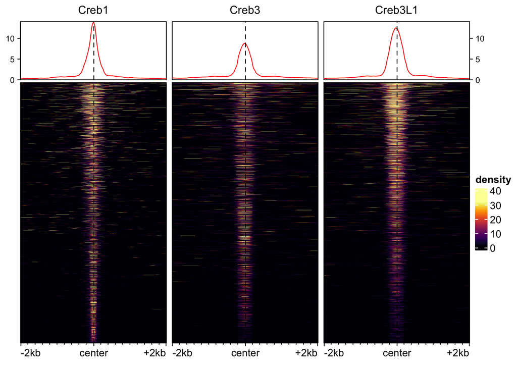

```r
# Plot enriched heatmaps
plotEnrichedHeatmaps(ese, use_raster=FALSE)
```

## Clustering

```r
# Clustering
set.seed(123)  # For reproducibility
cl <- clusterSignalMatrices(ese, k=4)
```

```
##   ~70% of the variance explained by clusters
```

```r
length(cl)
```

```
## [1] 2269
```

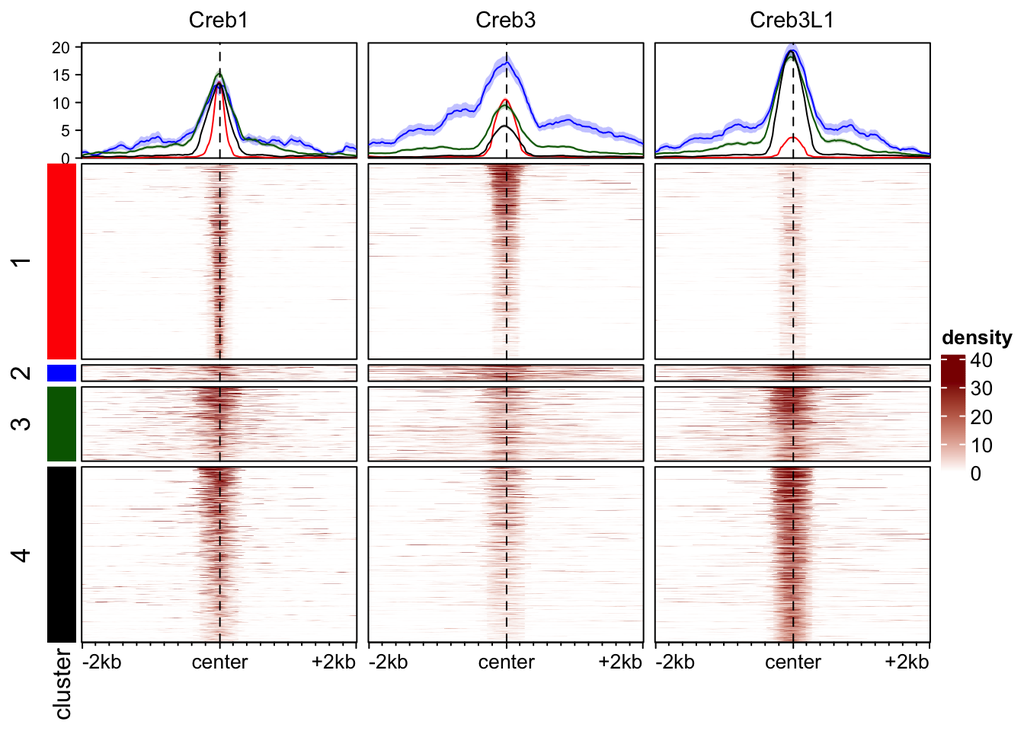

```r
rowData(ese)$cluster <- cl

# Plotting clusters with custom colors
mycolors <- c("1"="red", "2"="blue", "3"="darkgreen", "4"="black")
plotEnrichedHeatmaps(ese, row_split="cluster", mean_color=mycolors, colors=c("white","darkred"), use_raster=FALSE)
```

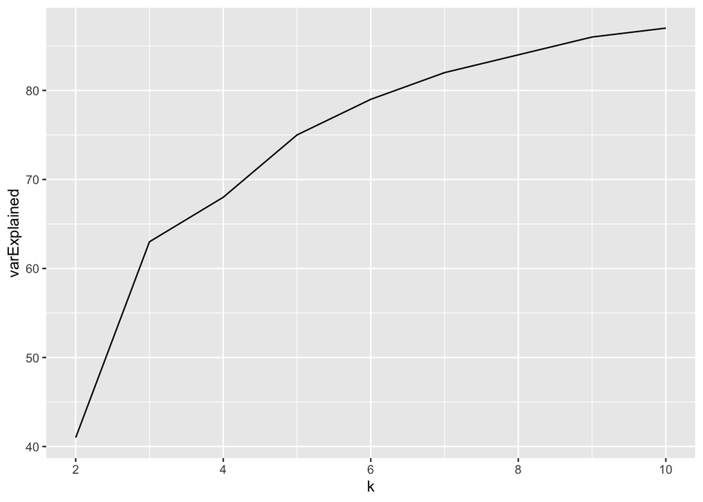

```r
# if we don't know how many clusters are good
cl2 <- clusterSignalMatrices(ese, k=2:10)
ggplot(cl2$varExplained, aes(k, varExplained)) + geom_line()
```

#Plotting just the averages:

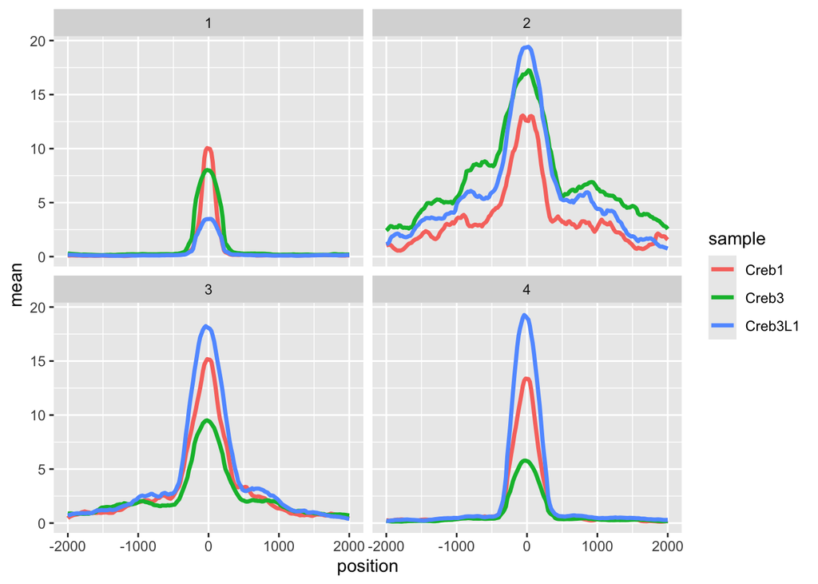

```r
d <- meltSignals(ese, splitBy=cl) # plot only average profiles of each cluster
ggplot(d, aes(position, mean, colour=sample)) + geom_line(size=1.2) + facet_wrap(~split)
```

#Clustering using relative signal instead:

```r
cl <- clusterSignalMatrices(ese, k=4, scaleRows = TRUE)
```

```
##   ~86% of the variance explained by clusters
```

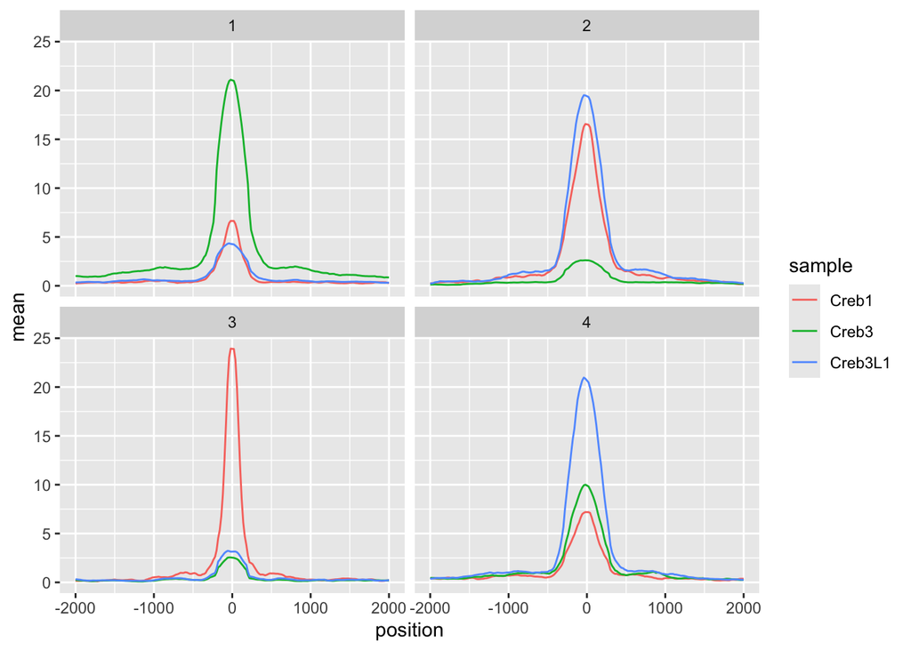

```r
d <- meltSignals(ese, splitBy=cl)
ggplot(d, aes(position, mean, colour=sample)) + geom_line() + facet_wrap(~split)
```

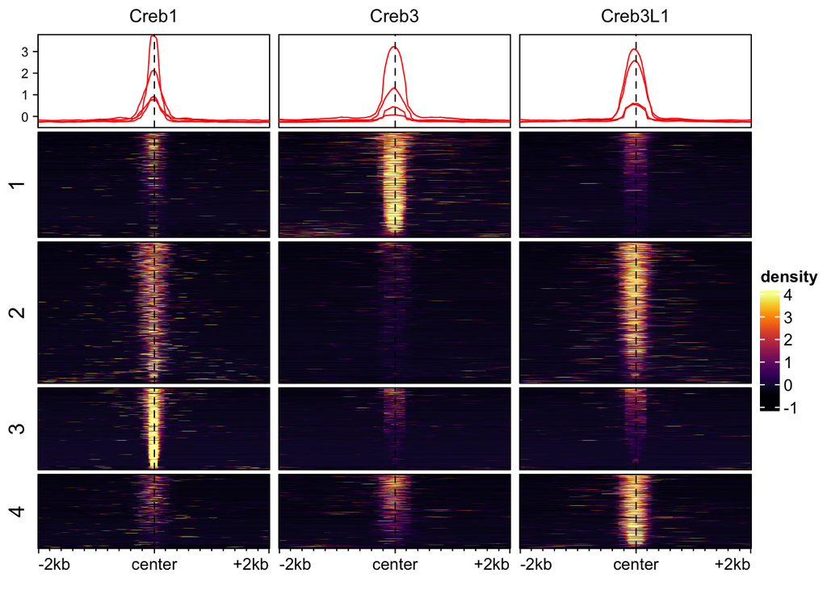

```r
plotEnrichedHeatmaps(ese, row_split = cl, scale_rows = "global", use_raster = FALSE)
```

## Enrichment analysis

#Find what’s enriched in one cluster with respect to the others:

```r
# we first split the regions by cluster:
split_regions <- split(rowRanges(ese), rowData(ese)$cluster)
split_regions
```

```
## GRangesList object of length 4:
## $`1`
## GRanges object with 961 ranges and 1 metadata column:
##                            seqnames              ranges strand |  cluster
##                               <Rle>           <IRanges>  <Rle> | <factor>
##         chr1:941785-942096     chr1       941785-942096      * |        1
##         chr1:943126-943501     chr1       943126-943501      * |        1
##         chr1:959088-959463     chr1       959088-959463      * |        1
##       chr1:1005099-1005514     chr1     1005099-1005514      * |        1
##       chr1:1033015-1033211     chr1     1033015-1033211      * |        1
##                        ...      ...                 ...    ... .      ...
##   chr1:247471156-247471564     chr1 247471156-247471564      * |        1
##   chr1:247857568-247857746     chr1 247857568-247857746      * |        1
##   chr1:247906352-247906767     chr1 247906352-247906767      * |        1
##   chr1:247936922-247937676     chr1 247936922-247937676      * |        1
##   chr1:248863011-248863586     chr1 248863011-248863586      * |        1
##   -------
##   seqinfo: 1 sequence from an unspecified genome; no seqlengths
##
## ...
## <3 more elements>
```

```r
res <- great(split_regions[["1"]], gene_sets="GO:BP", tss_source="mm10",
             background=regions, cores=2)
```

```
## * TSS source: TxDb.
```

```
## * check whether TxDb package 'TxDb.Mmusculus.UCSC.mm10.knownGene' is installed.
```

```
## * gene ID type in the extended TSS is 'Entrez Gene ID'.
```

```
## * restrict chromosomes to 'chr1, chr2, chr3, chr4, chr5, chr6, chr7, chr8, chr9, chr10,
##     chr11, chr12, chr13, chr14, chr15, chr16, chr17, chr18, chr19, chrX, chrY, chrM'.
```

```
## * 20585/24515 protein-coding genes left.
```

```
## * update seqinfo to the selected chromosomes.
```

```
## * TSS extension mode is 'basalPlusExt'.
```

```
## * construct the basal domains by extending 5000bp to upstream and 1000bp to downsteram of TSS.
```

```
## * calculate distances to neighbour regions.
```

```
## * extend to both sides until reaching the neighbour genes or to the maximal extension.
```

```
## * use GO:BP ontology with 15848 gene sets (source: org.Mm.eg.db).
```

```
## * check gene ID type in `gene_sets` and in `extended_tss`.
```

```
## * use self-defined background regions.
```

```
## * remove excluded regions from background.
```

```
## * overlap `gr` to background regions (based on midpoint).
```

```
## * in total 937 `gr`.
```

```
## * overlap extended TSS to background regions.
```

```
## * check which genes are in the gene sets.
```

```
## * only take gene sets with size >= 5.
```

```
## * in total 1300 gene sets.
```

```
## * overlap `gr` to every extended TSS.
```

```
## * perform binomial test for each biological term.
```

```r
res
```

```
## 937 regions are associated to 400 genes' extended TSSs.
##   TSS source: TxDb.Mmusculus.UCSC.mm10.knownGene
##   Genome: mm10
##   OrgDb: org.Mm.eg.db
##   Gene sets: GO:BP
##   Background: self-provided
## Mode: Basal plus extension
##   Proximal: 5000 bp upstream, 1000 bp downstream,
##   plus Distal: up to 1000000 bp
```

```r
bp <- getEnrichmentTables(res)
```

#We plot the top Biological Processes:

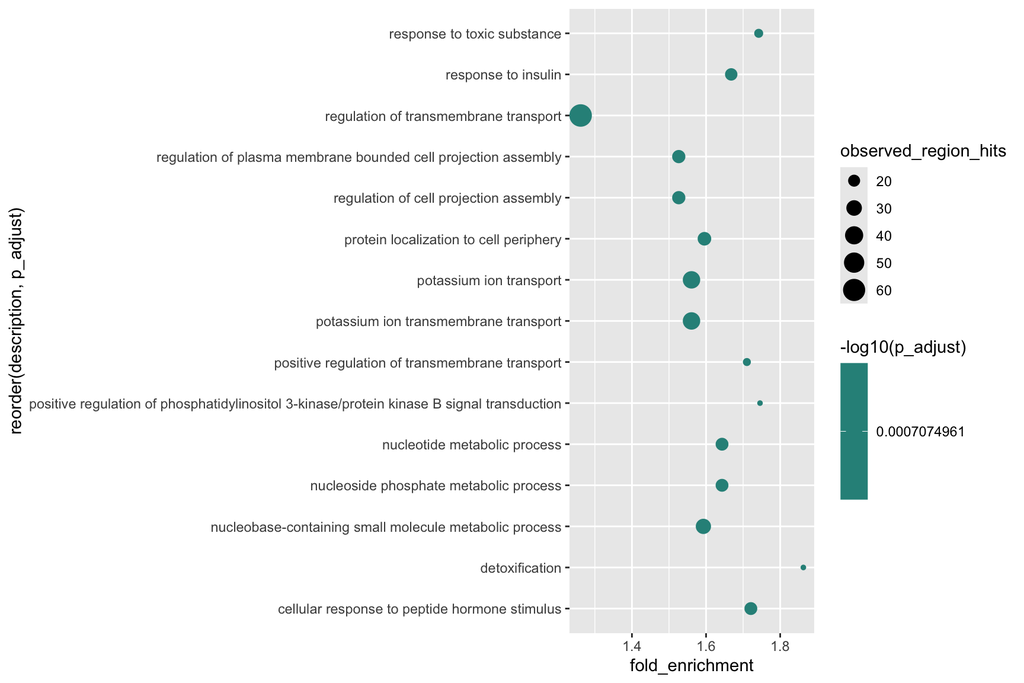

```r
ggplot(head(bp,15), aes(fold_enrichment, reorder(description, p_adjust),
                        size=observed_region_hits, color=-log10(p_adjust))) +
  geom_point() + scale_color_viridis_c()
```

### Results

#From the first clustering table: With four clusters, we can explain 70% of the variance. This is not bad, but normally one would choose k such that more than 80% of the variance is explained.

#When performing clustering with k ranging from 2-10 and plotting the average variance explained, it can be observed that with 7 clusters, more than 80% of the variance is explained. However, this may be an instance of overfitting. It is therefore recommended to continue with 4 clusters, as the probability of identifying additional clusters that are similar and can be merged together is high.

#When we examine the relative signals in lieu of the absolute signals, we gain a more discernible pattern. Consequently, CREB1 and CREB3L1 appear to diverge in their binding profiles, exhibiting less similarity than previously observed. The binding profile of CREB3 remained relatively consistent. It is noteworthy that, despite their shared phylogenetic origin, no cluster was identified where all three TFs exhibited equivalent binding profiles under the tested conditions.